# intro_to_lmer

Violet Brown

August 5, 2020

This code accompanies “An introduction to mixed effects modeling”

# Preliminaries

Install packages if they aren’t already installed

```r
if (!("lme4" %in% installed.packages())) install.packages("lme4")
if (!("tidyverse" %in% installed.packages())) install.packages("tidyverse")
if (!("afex" %in% installed.packages())) install.packages("afex")
```

Load packages

```r
library(lme4)
library(tidyverse)
library(afex)
```

Load data, and name that object “rt_data”

```r
rt_data <- read_csv("rt_dummy_data.csv")
```

View the first six rows of the data frame

```r
head(rt_data)
```

```
## # A tibble: 6 x 4
##     PID    RT modality   stim
##   <dbl> <dbl> <chr>      <chr>
## 1   301  1024 Audio-only gown
## 2   301   838 Audio-only might
## 3   301  1060 Audio-only fern
## 4   301   882 Audio-only vane
## 5   301   971 Audio-only pup
## 6   301  1064 Audio-only rise
```

Create an aggregated version that would be used in an ANOVA, and view the first six rows of that data frame

```r
ANOVA_data <- rt_data %>%
  group_by(PID, modality) %>%
  dplyr::summarise(RT = mean(RT))
head(ANOVA_data)
```

```
## # A tibble: 6 x 3
## # Groups:   PID [3]
##     PID modality       RT
##   <dbl> <chr>       <dbl>
## 1   301 Audio-only  1027.
## 2   301 Audiovisual 1002.
## 3   302 Audio-only  1047.
## 4   302 Audiovisual 1043.
## 5   303 Audio-only   883.
## 6   303 Audiovisual  938.
```

# Testing for an effect of modality on response time

Dummy code modality so that audio-only is the reference level

```r
rt_data$modality <- ifelse(rt_data$modality == "Audio-only", 0, 1)
```

Build a full model

```r
rt_full.mod <- lmer(RT ~ 1 + modality +
                      (1 + modality|PID) + (1 + modality|stim),
                    data = rt_data)
```

This model failed to converge. The first thing we’ll do is try the all_fit() function from the afex package to look for an optimizer that works.

```r
all_fit(rt_full.mod)
```

```
## bobyqa. : [OK]
## Nelder_Mead. : [OK]
## optimx.nlminb :
```

```
## [OK]
## optimx.L-BFGS-B :
```

```
## [OK]
## nloptwrap.NLOPT_LN_NELDERMEAD :
```

```
## [OK]
## nloptwrap.NLOPT_LN_BOBYQA :
```

```
## [OK]
## nmkbw. : [OK]
```

```
## $bobyqa.
## Linear mixed model fit by REML ['lmerModLmerTest']
## Formula: RT ~ 1 + modality + (1 + modality | PID) + (1 + modality | stim)
##    Data: rt_data
## REML criterion at convergence: 302385.7
## Random effects:
##  Groups   Name        Std.Dev. Corr
##  stim     (Intercept)  17.43
##           modality     14.72   0.16
##  PID      (Intercept) 168.98
##           modality     87.81   -0.17
##  Residual             255.46
## Number of obs: 21679, groups:  stim, 543; PID, 53
## Fixed Effects:
## (Intercept)     modality
##     1044.14        83.18
##
## $Nelder_Mead.
## Linear mixed model fit by REML ['lmerModLmerTest']
## Formula: RT ~ 1 + modality + (1 + modality | PID) + (1 + modality | stim)
##    Data: rt_data
## REML criterion at convergence: 302385.7
## Random effects:
##  Groups   Name        Std.Dev. Corr
##  stim     (Intercept)  17.43
##           modality     14.72   0.16
##  PID      (Intercept) 168.98
##           modality     87.81   -0.17
##  Residual             255.46
## Number of obs: 21679, groups:  stim, 543; PID, 53
## Fixed Effects:
## (Intercept)     modality
##     1044.14        83.18
##
## $optimx.nlminb
## Linear mixed model fit by REML ['lmerModLmerTest']
## Formula: RT ~ 1 + modality + (1 + modality | PID) + (1 + modality | stim)
##    Data: rt_data
## REML criterion at convergence: 302385.7
## Random effects:
```

[output cut: 66 more lines]

```
## Linear mixed model fit by REML ['lmerModLmerTest']
## Formula: RT ~ 1 + modality + (1 + modality | PID) + (1 + modality | stim)
##    Data: rt_data
## REML criterion at convergence: 302385.7
## Random effects:
##  Groups   Name        Std.Dev. Corr
##  stim     (Intercept)  17.44
##           modality     14.72   0.16
##  PID      (Intercept) 168.96
##           modality     87.80   -0.17
##  Residual             255.46
## Number of obs: 21679, groups:  stim, 543; PID, 53
## Fixed Effects:
## (Intercept)     modality
##     1044.14        83.18
```

The bobyqa optimizer should work.

```r
rt_full.mod <- lmer(RT ~ 1 + modality +
                      (1 + modality|PID) + (1 + modality|stim),
                    data = rt_data,
                    control = lmerControl(optimizer = "bobyqa"))
```

Run the all_fit() function from the afex() package for demonstration purposes

```r
all_fit(rt_full.mod)
```

```
## bobyqa. : [OK]
## Nelder_Mead. : [OK]
## optimx.nlminb : [OK]
## optimx.L-BFGS-B :
```

```
## [OK]
## nloptwrap.NLOPT_LN_NELDERMEAD :
```

```
## [OK]
## nloptwrap.NLOPT_LN_BOBYQA :
```

```
## [OK]
## nmkbw. : [OK]
```

```
## $bobyqa.
## Linear mixed model fit by REML ['lmerModLmerTest']
## Formula: RT ~ 1 + modality + (1 + modality | PID) + (1 + modality | stim)
##    Data: rt_data
## REML criterion at convergence: 302385.7
## Random effects:
##  Groups   Name        Std.Dev. Corr
##  stim     (Intercept)  17.43
##           modality     14.72   0.16
##  PID      (Intercept) 168.98
##           modality     87.81   -0.17
##  Residual             255.46
## Number of obs: 21679, groups:  stim, 543; PID, 53
## Fixed Effects:
## (Intercept)     modality
##     1044.14        83.18
##
## $Nelder_Mead.
## Linear mixed model fit by REML ['lmerModLmerTest']
## Formula: RT ~ 1 + modality + (1 + modality | PID) + (1 + modality | stim)
##    Data: rt_data
## REML criterion at convergence: 302385.7
## Random effects:
##  Groups   Name        Std.Dev. Corr
##  stim     (Intercept)  17.43
##           modality     14.72   0.16
##  PID      (Intercept) 168.98
##           modality     87.81   -0.17
##  Residual             255.46
## Number of obs: 21679, groups:  stim, 543; PID, 53
## Fixed Effects:
## (Intercept)     modality
##     1044.14        83.18
##
## $optimx.nlminb
## Linear mixed model fit by REML ['lmerModLmerTest']
## Formula: RT ~ 1 + modality + (1 + modality | PID) + (1 + modality | stim)
##    Data: rt_data
## REML criterion at convergence: 302385.7
## Random effects:
```

[output cut: 66 more lines]

```
## Linear mixed model fit by REML ['lmerModLmerTest']
## Formula: RT ~ 1 + modality + (1 + modality | PID) + (1 + modality | stim)
##    Data: rt_data
## REML criterion at convergence: 302385.7
## Random effects:
##  Groups   Name        Std.Dev. Corr
##  stim     (Intercept)  17.44
##           modality     14.72   0.16
##  PID      (Intercept) 168.96
##           modality     87.80   -0.17
##  Residual             255.46
## Number of obs: 21679, groups:  stim, 543; PID, 53
## Fixed Effects:
## (Intercept)     modality
##     1044.14        83.18
```

Build a reduced model that doesn’t contained the fixed effect of modality, but is otherwise identical to the full model (including the random effects structure and control parameter)

```r
rt_reduced.mod <- lmer(RT ~ 1 +
                         (1 + modality|stim) + (1 + modality|PID),
                       data = rt_data,
                       control = lmerControl(optimizer = "bobyqa"))
```

Test for an effect of modality via a likelihood ratio test

```r
anova(rt_reduced.mod, rt_full.mod)
```

```
## refitting model(s) with ML (instead of REML)
```

```
## Data: rt_data
## Models:
## rt_reduced.mod: RT ~ 1 + (1 + modality | stim) + (1 + modality | PID)
## rt_full.mod: RT ~ 1 + modality + (1 + modality | PID) + (1 + modality | stim)
##                npar    AIC    BIC  logLik deviance  Chisq Df Pr(>Chisq)
## rt_reduced.mod    8 302449 302513 -151217   302433
## rt_full.mod       9 302419 302491 -151200   302401 32.385  1  1.264e-08 ***
## ---
## Signif. codes:  0 '***' 0.001 '**' 0.01 '*' 0.05 '.' 0.1 ' ' 1
```

Use the mixed() function from the afex package for demonstration purposes (this appears in the Likelihood Ratio Tests portion of the paper)

```r
mixed(RT ~ 1 + modality +
         (1 + modality|PID) + (1 + modality|stim),
       data = rt_data,
       control = lmerControl(optimizer = "bobyqa"),
       method = 'LRT')
```

```
## Contrasts set to contr.sum for the following variables: stim
```

```
## Numerical variables NOT centered on 0: modality
## If in interactions, interpretation of lower order (e.g., main) effects difficult.
```

```
## REML argument to lmer() set to FALSE for method = 'PB' or 'LRT'
```

```
## Fitting 2 (g)lmer() models:
## [..]
```

```
## Mixed Model Anova Table (Type 3 tests, LRT-method)
##
## Model: RT ~ 1 + modality + (1 + modality | PID) + (1 + modality | stim)
## Data: rt_data
## Df full model: 9
##     Effect df     Chisq p.value
## 1 modality  1 32.39 ***   <.001
## ---
## Signif. codes:  0 '***' 0.001 '**' 0.01 '*' 0.05 '+' 0.1 ' ' 1
```

View summary output

```r
summary(rt_full.mod)
```

```
## Linear mixed model fit by REML. t-tests use Satterthwaite's method [
## lmerModLmerTest]
## Formula: RT ~ 1 + modality + (1 + modality | PID) + (1 + modality | stim)
##    Data: rt_data
## Control: lmerControl(optimizer = "bobyqa")
##
## REML criterion at convergence: 302385.7
##
## Scaled residuals:
##     Min      1Q  Median      3Q     Max
## -3.3646 -0.6964 -0.0140  0.5886  5.0003
##
## Random effects:
##  Groups   Name        Variance Std.Dev. Corr
##  stim     (Intercept)   303.9   17.43
##           modality      216.7   14.72   0.16
##  PID      (Intercept) 28552.9  168.98
##           modality     7709.8   87.81   -0.17
##  Residual             65258.8  255.46
## Number of obs: 21679, groups:  stim, 543; PID, 53
##
## Fixed effects:
##             Estimate Std. Error      df t value Pr(>|t|)
## (Intercept)  1044.14      23.36   52.14  44.704  < 2e-16 ***
## modality       83.18      12.58   52.10   6.615 2.02e-08 ***
## ---
## Signif. codes:  0 '***' 0.001 '**' 0.01 '*' 0.05 '.' 0.1 ' ' 1
##
## Correlation of Fixed Effects:
##          (Intr)
## modality -0.178
```

The parameter estimate for the effect of condition is 83.18, which means that in this dummy data, participants are on average 83 ms slower in the audiovisual relative to the audio-only condition.

Run the coef() function to examine individual participant and item intercept and slope estimates

```r
coef(rt_full.mod)
```

```
## $stim
##        (Intercept) modality
## babe      1038.921 82.11521
## back      1050.914 86.52633
## bad       1041.122 81.12267
## bag       1042.896 86.40601
## bake      1039.395 81.75292
## balk      1042.560 84.17726
## ball      1035.114 80.50253
## bane      1055.741 83.15418
## bang      1048.652 85.51499
## bar       1042.990 82.57040
## base      1043.169 81.00298
## bash      1036.544 79.31510
## batch     1047.446 84.84039
## bath      1039.152 81.59490
## bathe     1043.921 77.52526
## bead      1037.029 78.75316
## beak      1042.654 84.36902
## beam      1040.067 79.28126
## bear      1040.514 83.76442
## beat      1049.312 84.73015
## beg       1044.947 85.99855
## bib       1048.505 83.32998
## bide      1046.706 84.50432
## big       1044.807 84.21706
## bin       1045.735 83.48756
## birth     1022.948 72.74012
## bit       1046.026 84.01293
## boat      1039.346 79.28319
## bog       1041.345 80.92930
## bomb      1045.924 85.51499
## booth     1039.411 80.25993
## booze     1051.868 86.61126
## botch     1040.909 78.78911
## bud       1034.365 79.13435
## budge     1044.947 84.51831
## bun       1034.580 79.54537
## burp      1033.454 75.26900
## bus       1033.021 79.51769
```

[output cut: 549 more lines]

```
## 353   1103.8173 155.151474
## 354   1074.6543 154.892038
## 355   1192.9344  89.264188
## 356    907.2052 397.764355
## 357    910.5673  81.928193
## 358    963.0962  33.338247
## 359   1087.6474 -39.273777
## 360   1070.4021  26.771336
## 361    982.1810 131.300510
## 362    953.3700  56.194590
## 363    920.7194  43.641068
## 364   1003.5099  75.844905
##
## attr(,"class")
## [1] "coef.mer"
```

# Testing for an interaction between modality and SNR

Load the data. Note that it’s actually the same as the original data frame, but it has an extra column containing SNR. We could have been dealing with this data frame the whole time, but having an extra variable that we’re not using can be confusing, so I waited to introduce it until now.

```r
rt_data_interaction <- read_csv("rt_dummy_data_interaction.csv")
```

Dummy code modality and SNR so that audio-only and easy are the reference levels

```r
rt_data_interaction$modality <- ifelse(rt_data_interaction$modality == "Audio-only", 0, 1)
rt_data_interaction$SNR <- ifelse(rt_data_interaction$SNR == "Easy", 0, 1)
```

Build the full model, which includes all by-participant and by-item random effects except the interaction between modality and SNR, which was not included because in my experience models with random effects structures that complex will almost certainly encounter estimation issues for this kind of data and we will need to simplify the random effects structure anyway. I also want to avoid having overly complex random effects structures because this can limit power (see Matuschek et al., 2017).

```r
rt_int.mod <- lmer(RT ~ 1 + modality + SNR + modality:SNR +
                     (1 + modality + SNR|stim) + (1 + modality + SNR|PID),
                   data = rt_data_interaction)
```

This model produced a singular fit, indicating that there are some problems with estimation going on. We’ll try using the all_fit() function from the afex package to see if another optimizer will work.

```r
all_fit(rt_int.mod)
```

```
## bobyqa. :
```

```
## boundary (singular) fit: see ?isSingular
```

```
## [OK]
## Nelder_Mead. :
```

```
## boundary (singular) fit: see ?isSingular
```

```
## [OK]
## optimx.nlminb :
```

```
## boundary (singular) fit: see ?isSingular
```

```
## [OK]
## optimx.L-BFGS-B :
```

```
## boundary (singular) fit: see ?isSingular
```

```
## [OK]
## nloptwrap.NLOPT_LN_NELDERMEAD :
```

```
## [OK]
## nloptwrap.NLOPT_LN_BOBYQA :
```

```
## [OK]
## nmkbw. :
```

```
## boundary (singular) fit: see ?isSingular
```

```
## [OK]
```

```
## $bobyqa.
## Linear mixed model fit by REML ['lmerModLmerTest']
## Formula: RT ~ 1 + modality + SNR + modality:SNR + (1 + modality + SNR |
##     stim) + (1 + modality + SNR | PID)
##    Data: rt_data_interaction
## REML criterion at convergence: 301137.3
## Random effects:
##  Groups   Name        Std.Dev. Corr
##  stim     (Intercept)  18.184
##           modality      6.729   1.00
##           SNR           3.401  -1.00 -1.00
##  PID      (Intercept) 159.765
##           modality     89.722  -0.03
##           SNR         101.747   0.02 -0.47
##  Residual             247.491
## Number of obs: 21679, groups:  stim, 543; PID, 53
## Fixed Effects:
##  (Intercept)      modality           SNR  modality:SNR
##       998.82         98.52         92.36        -29.56
## optimizer (bobyqa) convergence code: 0 (OK) ; 0 optimizer warnings; 1 lme4 warnings
##
## $Nelder_Mead.
## Linear mixed model fit by REML ['lmerModLmerTest']
## Formula: RT ~ 1 + modality + SNR + modality:SNR + (1 + modality + SNR |
##     stim) + (1 + modality + SNR | PID)
##    Data: rt_data_interaction
## REML criterion at convergence: 301152.4
## Random effects:
##  Groups   Name        Std.Dev. Corr
##  stim     (Intercept)   0.000
##           modality     18.122   NaN
##           SNR           9.198   NaN  0.96
##  PID      (Intercept) 186.856
##           modality    101.671  -0.32
##           SNR         109.862   0.27 -0.56
##  Residual             247.651
## Number of obs: 21679, groups:  stim, 543; PID, 53
## Fixed Effects:
##  (Intercept)      modality           SNR  modality:SNR
##       998.80         98.49         92.34        -29.52
```

[output cut: 91 more lines]

```
## REML criterion at convergence: 301137.3
## Random effects:
##  Groups   Name        Std.Dev. Corr
##  stim     (Intercept)  18.187
##           modality      6.725   1.00
##           SNR           3.401  -1.00 -1.00
##  PID      (Intercept) 159.763
##           modality     89.731  -0.03
##           SNR         101.740   0.02 -0.47
##  Residual             247.491
## Number of obs: 21679, groups:  stim, 543; PID, 53
## Fixed Effects:
##  (Intercept)      modality           SNR  modality:SNR
##       998.82         98.52         92.36        -29.56
## optimizer (nmkbw) convergence code: 0 (OK) ; 0 optimizer warnings; 1 lme4 warnings
```

All of these produced a singular fit, and the estimation issues seem to be coming from the item random effects. Given that all the optimizers produced very similar estimates for fixed and random effects, and the item random effects (particularly the slopes) are contributing very little to the total variance using all of the optimizers, we’ll try removing the by-item random slopes for modality or SNR, and testing those against the full model via likelihood ratio tests to see if we can remove those (refit = FALSE because we are testing random effects, not fixed effects).

```r
rt_int.mod <- lmer(RT ~ 1 + modality + SNR + modality:SNR +
                     (1 + modality + SNR|stim) + (1 + modality + SNR|PID),
                   data = rt_data_interaction)
rt_int_no_modality_stim.mod <- lmer(RT ~ 1 + modality + SNR + modality:SNR +
                     (1 + SNR|stim) + (1 + modality + SNR|PID),
                   data = rt_data_interaction)
```

```
## boundary (singular) fit: see ?isSingular
```

```r
rt_int_no_SNR_stim.mod <- lmer(RT ~ 1 + modality + SNR + modality:SNR +
                     (1 + modality|stim) + (1 + modality + SNR|PID),
                   data = rt_data_interaction)
```

```
## boundary (singular) fit: see ?isSingular
```

```r
anova(rt_int_no_modality_stim.mod, rt_int.mod, refit = FALSE)
```

```
## Data: rt_data_interaction
## Models:
## rt_int_no_modality_stim.mod: RT ~ 1 + modality + SNR + modality:SNR + (1 + SNR | stim) + (1 +
## rt_int_no_modality_stim.mod:     modality + SNR | PID)
## rt_int.mod: RT ~ 1 + modality + SNR + modality:SNR + (1 + modality + SNR |
## rt_int.mod:     stim) + (1 + modality + SNR | PID)
##                             npar    AIC    BIC  logLik deviance  Chisq Df
## rt_int_no_modality_stim.mod   14 301166 301278 -150569   301138
## rt_int.mod                    17 301171 301307 -150569   301137 0.9413  3
##                             Pr(>Chisq)
## rt_int_no_modality_stim.mod
## rt_int.mod                      0.8154
```

```r
anova(rt_int_no_SNR_stim.mod, rt_int.mod, refit = FALSE)
```

```
## Data: rt_data_interaction
## Models:
## rt_int_no_SNR_stim.mod: RT ~ 1 + modality + SNR + modality:SNR + (1 + modality | stim) +
## rt_int_no_SNR_stim.mod:     (1 + modality + SNR | PID)
## rt_int.mod: RT ~ 1 + modality + SNR + modality:SNR + (1 + modality + SNR |
## rt_int.mod:     stim) + (1 + modality + SNR | PID)
##                        npar    AIC    BIC  logLik deviance  Chisq Df Pr(>Chisq)
## rt_int_no_SNR_stim.mod   14 301166 301277 -150569   301138
## rt_int.mod               17 301171 301307 -150569   301137 0.2683  3     0.9659
```

It looks like the model with both random slopes does not differ from either reduced model, so we’ll start by removing the random slope that is contributing less to the total variance according to all previous models (the by-item random slope for SNR).

```r
rt_int.mod <- lmer(RT ~ 1 + modality + SNR + modality:SNR +
                     (1 + modality|stim) + (1 + modality + SNR|PID),
                   data = rt_data_interaction)
```

```
## boundary (singular) fit: see ?isSingular
```

This one produced a singular fit (we already knew that would happen because we built the same model above), so let’s try all_fit()

```r
all_fit(rt_int.mod)
```

```
## bobyqa. :
```

```
## boundary (singular) fit: see ?isSingular
```

```
## [OK]
## Nelder_Mead. :
```

```
## [OK]
## optimx.nlminb :
```

```
## [OK]
## optimx.L-BFGS-B :
```

```
## boundary (singular) fit: see ?isSingular
```

```
## [OK]
## nloptwrap.NLOPT_LN_NELDERMEAD :
```

```
## boundary (singular) fit: see ?isSingular
```

```
## [OK]
## nloptwrap.NLOPT_LN_BOBYQA :
```

```
## boundary (singular) fit: see ?isSingular
```

```
## [OK]
## nmkbw. :
```

```
## [OK]
```

```
## $bobyqa.
## Linear mixed model fit by REML ['lmerModLmerTest']
## Formula: RT ~ 1 + modality + SNR + modality:SNR + (1 + modality | stim) +
##     (1 + modality + SNR | PID)
##    Data: rt_data_interaction
## REML criterion at convergence: 301137.6
## Random effects:
##  Groups   Name        Std.Dev. Corr
##  stim     (Intercept)  16.414
##           modality      6.928  1.00
##  PID      (Intercept) 159.747
##           modality     89.694  -0.03
##           SNR         101.742   0.02 -0.47
##  Residual             247.498
## Number of obs: 21679, groups:  stim, 543; PID, 53
## Fixed Effects:
##  (Intercept)      modality           SNR  modality:SNR
##       998.82         98.52         92.36        -29.55
## optimizer (bobyqa) convergence code: 0 (OK) ; 0 optimizer warnings; 1 lme4 warnings
##
## $Nelder_Mead.
## Linear mixed model fit by REML ['lmerModLmerTest']
## Formula: RT ~ 1 + modality + SNR + modality:SNR + (1 + modality | stim) +
##     (1 + modality + SNR | PID)
##    Data: rt_data_interaction
## REML criterion at convergence: 301167.5
## Random effects:
##  Groups   Name        Std.Dev. Corr
##  stim     (Intercept)   3.174
##           modality     26.456  -0.74
##  PID      (Intercept) 251.305
##           modality     89.545  -0.06
##           SNR         116.118  -0.21 -0.45
##  Residual             247.522
## Number of obs: 21679, groups:  stim, 543; PID, 53
## Fixed Effects:
##  (Intercept)      modality           SNR  modality:SNR
##       998.79         98.48         92.29        -29.48
## optimizer (Nelder_Mead) convergence code: 0 (OK) ; 0 optimizer warnings; 2 lme4 warnings
##
```

[output cut: 84 more lines]

```
##    Data: rt_data_interaction
## REML criterion at convergence: 301137.6
## Random effects:
##  Groups   Name        Std.Dev. Corr
##  stim     (Intercept)  16.415
##           modality      6.926  1.00
##  PID      (Intercept) 159.747
##           modality     89.693  -0.03
##           SNR         101.742   0.02 -0.47
##  Residual             247.498
## Number of obs: 21679, groups:  stim, 543; PID, 53
## Fixed Effects:
##  (Intercept)      modality           SNR  modality:SNR
##       998.82         98.52         92.36        -29.55
## optimizer (nmkbw) convergence code: 0 (OK) ; 0 optimizer warnings; 1 lme4 warnings
```

The Nelder-Mead optimizer might work, so we’ll try that one

```r
rt_int.mod <- lmer(RT ~ 1 + modality + SNR + modality:SNR +
                     (1 + modality|stim) + (1 + modality + SNR|PID),
                   data = rt_data_interaction,
                   control = lmerControl(optimizer = 'Nelder_Mead'))
```

```
## Warning in checkConv(attr(opt, "derivs"), opt$par, ctrl = control$checkConv, :
## Model failed to converge: degenerate Hessian with 1 negative eigenvalues
```

```
## Warning: Model failed to converge with 1 negative eigenvalue: -4.1e+03
```

That led to convergence issues. It looks like all of these optimizers lead to estimation issues, so we’ll try removing the correlation between the random intercept for stimulus and the by-stimulus random slope for modality (this is ok in this situation because we aren’t actually interested in that correlation).

```r
rt_int.mod <- lmer(RT ~ 1 + modality + SNR + modality:SNR +
                     (0 + modality|stim) + (1|stim) + (1 + modality + SNR|PID),
                   data = rt_data_interaction)
```

This led to a convergence warning, so we’ll try all_fit() again

```r
all_fit(rt_int.mod)
```

```
## bobyqa. : [OK]
## Nelder_Mead. : [OK]
## optimx.nlminb : [OK]
## optimx.L-BFGS-B :
```

```
## Warning in checkConv(attr(opt, "derivs"), opt$par, ctrl = control$checkConv, :
## Model failed to converge with max|grad| = 0.0135467 (tol = 0.002, component 1)
```

```
## [OK]
## nloptwrap.NLOPT_LN_NELDERMEAD : [OK]
## nloptwrap.NLOPT_LN_BOBYQA : [OK]
## nmkbw. : [OK]
```

```
## $bobyqa.
## Linear mixed model fit by REML ['lmerModLmerTest']
## Formula: RT ~ 1 + modality + SNR + modality:SNR + (0 + modality | stim) +
##     (1 | stim) + (1 + modality + SNR | PID)
##    Data: rt_data_interaction
## REML criterion at convergence: 301138.2
## Random effects:
##  Groups   Name        Std.Dev. Corr
##  stim     modality     12.03
##  stim.1   (Intercept)  18.88
##  PID      (Intercept) 159.76
##           modality     89.69   -0.03
##           SNR         101.76    0.02 -0.47
##  Residual             247.46
## Number of obs: 21679, groups:  stim, 543; PID, 53
## Fixed Effects:
##  (Intercept)      modality           SNR  modality:SNR
##       998.82         98.51         92.34        -29.53
##
## $Nelder_Mead.
## Linear mixed model fit by REML ['lmerModLmerTest']
## Formula: RT ~ 1 + modality + SNR + modality:SNR + (0 + modality | stim) +
##     (1 | stim) + (1 + modality + SNR | PID)
##    Data: rt_data_interaction
## REML criterion at convergence: 301138.2
## Random effects:
##  Groups   Name        Std.Dev. Corr
##  stim     modality     12.03
##  stim.1   (Intercept)  18.88
##  PID      (Intercept) 159.76
##           modality     89.69   -0.03
##           SNR         101.76    0.02 -0.47
##  Residual             247.46
## Number of obs: 21679, groups:  stim, 543; PID, 53
## Fixed Effects:
##  (Intercept)      modality           SNR  modality:SNR
##       998.82         98.51         92.34        -29.53
##
## $optimx.nlminb
## Linear mixed model fit by REML ['lmerModLmerTest']
```

[output cut: 78 more lines]

```
##     (1 | stim) + (1 + modality + SNR | PID)
##    Data: rt_data_interaction
## REML criterion at convergence: 301138.2
## Random effects:
##  Groups   Name        Std.Dev. Corr
##  stim     modality     12.04
##  stim.1   (Intercept)  18.88
##  PID      (Intercept) 159.76
##           modality     89.70   -0.03
##           SNR         101.77    0.02 -0.47
##  Residual             247.46
## Number of obs: 21679, groups:  stim, 543; PID, 53
## Fixed Effects:
##  (Intercept)      modality           SNR  modality:SNR
##       998.82         98.51         92.34        -29.53
```

The bobyqa optimizer might work, so we’ll try that

```r
rt_int.mod <- lmer(RT ~ 1 + modality + SNR + modality:SNR +
                     (0 + modality|stim) + (1|stim) + (1 + modality + SNR|PID),
                   data = rt_data_interaction,
                   control = lmerControl(optimizer = 'bobyqa'))
```

Looks like that converged, but let’s examine the random effects output to make sure estimation went smoothly.

```r
summary(rt_int.mod)
```

```
## Linear mixed model fit by REML. t-tests use Satterthwaite's method [
## lmerModLmerTest]
## Formula: RT ~ 1 + modality + SNR + modality:SNR + (0 + modality | stim) +
##     (1 | stim) + (1 + modality + SNR | PID)
##    Data: rt_data_interaction
## Control: lmerControl(optimizer = "bobyqa")
##
## REML criterion at convergence: 301138.2
##
## Scaled residuals:
##     Min      1Q  Median      3Q     Max
## -3.5354 -0.6949 -0.0045  0.5972  4.8706
##
## Random effects:
##  Groups   Name        Variance Std.Dev. Corr
##  stim     modality      144.7   12.03
##  stim.1   (Intercept)   356.3   18.88
##  PID      (Intercept) 25522.7  159.76
##           modality     8044.7   89.69   -0.03
##           SNR         10355.6  101.76    0.02 -0.47
##  Residual             61234.2  247.46
## Number of obs: 21679, groups:  stim, 543; PID, 53
##
## Fixed effects:
##               Estimate Std. Error        df t value Pr(>|t|)
## (Intercept)    998.824     22.214    52.729  44.964  < 2e-16 ***
## modality        98.510     13.199    59.065   7.464 4.41e-10 ***
## SNR             92.339     14.790    58.004   6.243 5.39e-08 ***
## modality:SNR   -29.532      6.755 21298.850  -4.372 1.24e-05 ***
## ---
## Signif. codes:  0 '***' 0.001 '**' 0.01 '*' 0.05 '.' 0.1 ' ' 1
##
## Correlation of Fixed Effects:
##             (Intr) modlty SNR
## modality    -0.063
## SNR         -0.014 -0.354
## modalty:SNR  0.074 -0.247 -0.232
```

Looks ok! We’ll stick with this one.

# Testing for an effect of modality on intelligibility (binomial)

Load data and name it acc_data

```r
acc_data <- read_csv("acc_dummy_data.csv")
```

Dummy code modality with audio-only as the reference level

```r
acc_data$modality <- ifelse(acc_data$modality == "Audio-only", 0, 1)
```

Make PID and stim factors

```r
acc_data$PID <- as.factor(acc_data$PID)
acc_data$stim <- as.factor(acc_data$stim)
```

Build a full model

```r
acc_full.mod <- glmer(acc ~ 1 + modality +
                        (1 + modality|PID) + (1 + modality|stim),
                      data = acc_data,
                      family = binomial)
```

Check random effects output

```r
summary(acc_full.mod)
```

```
## Generalized linear mixed model fit by maximum likelihood (Laplace
##   Approximation) [glmerMod]
##  Family: binomial  ( logit )
## Formula: acc ~ 1 + modality + (1 + modality | PID) + (1 + modality | stim)
##    Data: acc_data
##
##      AIC      BIC   logLik deviance df.resid
##  27988.6  28054.8 -13986.3  27972.6    28799
##
## Scaled residuals:
##     Min      1Q  Median      3Q     Max
## -6.2346  0.1411  0.3436  0.5606  2.0937
##
## Random effects:
##  Groups Name        Variance Std.Dev. Corr
##  stim   (Intercept) 0.72085  0.8490
##         modality    0.46663  0.6831   -0.06
##  PID    (Intercept) 0.04346  0.2085
##         modality    0.04903  0.2214   -0.15
## Number of obs: 28807, groups:  stim, 543; PID, 53
##
## Fixed effects:
##             Estimate Std. Error z value Pr(>|z|)
## (Intercept)  0.77987    0.05043   15.46   <2e-16 ***
## modality     1.43094    0.05734   24.95   <2e-16 ***
## ---
## Signif. codes:  0 '***' 0.001 '**' 0.01 '*' 0.05 '.' 0.1 ' ' 1
##
## Correlation of Fixed Effects:
##          (Intr)
## modality -0.201
```

Build a reduced model lacking the fixed effect for modality

```r
acc_reduced.mod <- glmer(acc ~ 1 +
                           (1 + modality|PID) + (1 + modality|stim),
                         data = acc_data,
                         family = binomial)
```

Conduct a likelihood ratio test to see if the effect of block (audio-only versus audiovisual) is significant

```r
anova(acc_reduced.mod, acc_full.mod)
```

```
## Data: acc_data
## Models:
## acc_reduced.mod: acc ~ 1 + (1 + modality | PID) + (1 + modality | stim)
## acc_full.mod: acc ~ 1 + modality + (1 + modality | PID) + (1 + modality | stim)
##                 npar   AIC   BIC logLik deviance  Chisq Df Pr(>Chisq)
## acc_reduced.mod    7 28147 28205 -14067    28133
## acc_full.mod       8 27989 28055 -13986    27973 160.78  1  < 2.2e-16 ***
## ---
## Signif. codes:  0 '***' 0.001 '**' 0.01 '*' 0.05 '.' 0.1 ' ' 1
```

# Fixed-effects only, random intercepts, and random slopes plots

Load data

```r
figuredata <- read_csv("figure_data.csv")
```

Make PID a factor

```r
figuredata$PID <- as.factor(figuredata$PID)
```

## Fixed-effects only regression plot

Build regression model and view the summary output to look at the residuals

```r
ols.mod <- lm(yvar ~ xvar, data = figuredata)

summary(ols.mod)
```

```
##
## Call:
## lm(formula = yvar ~ xvar, data = figuredata)
##
## Residuals:
##     Min      1Q  Median      3Q     Max
## -721.36 -233.80    3.13  361.59  561.08
##
## Coefficients:
##             Estimate Std. Error t value Pr(>|t|)
## (Intercept)   582.92     180.88   3.223  0.00614 **
## xvar          119.84      30.64   3.911  0.00157 **
## ---
## Signif. codes:  0 '***' 0.001 '**' 0.01 '*' 0.05 '.' 0.1 ' ' 1
##
## Residual standard error: 410.2 on 14 degrees of freedom
## Multiple R-squared:  0.5221, Adjusted R-squared:  0.4879
## F-statistic: 15.29 on 1 and 14 DF,  p-value: 0.001568
```

Build a fixed effects only plot

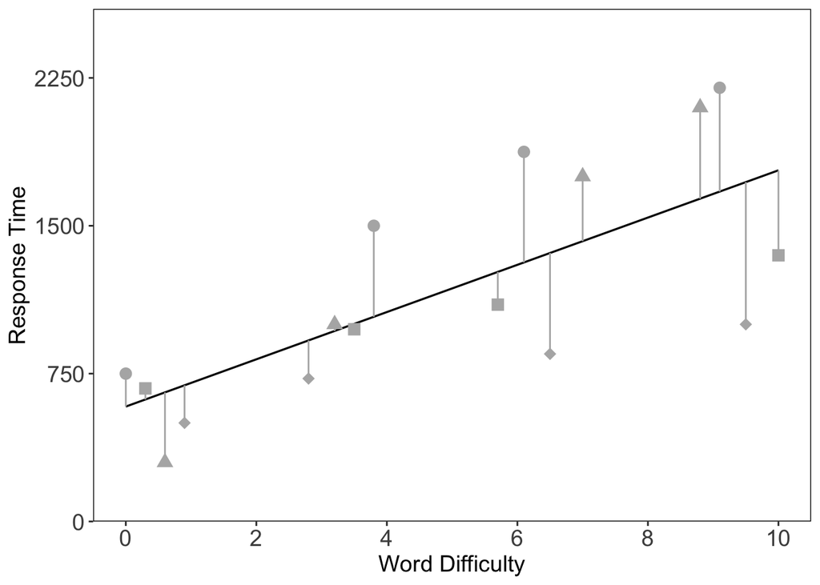

```r
ggplot(figuredata, aes(x = xvar, y = yvar)) +
  stat_smooth(method = lm, se = FALSE, linetype = "solid",
              color = "black", size = .6) +
  geom_point(aes(shape = PID), size = 3.25, color = "grey70") +
  scale_shape_manual(values = c(15, 16, 17, 18)) +
  geom_segment(aes(x = xvar, xend = xvar,
                   y = yvar, yend = fitted(ols.mod)),
               color = "grey70") +
  scale_y_continuous(expand = c(0, 0), breaks = c(0, 750, 1500, 2250, 3000),
                     limits = c(0, 2600)) +
  scale_x_continuous(expand = c(0, 0), breaks = c(0, 2, 4, 6, 8, 10),
                     limits = c(-0.5, 10.5)) +
  theme(panel.background = element_blank(),
        panel.grid.major = element_blank(),
        panel.grid.minor = element_blank(),
        panel.border = element_rect(colour = "black", fill = NA),
        legend.position = "none",
        axis.text = element_text(size = 14),
        axis.title = element_text(size = 14)) +
  labs (x = "Word Difficulty", y = "Response Time")
```

Save the figure

```r
ggsave("fixed_effects_plot.png", units = "in", width = 9, height = 6, dpi = 300)
```

## Random intercepts plot

Build the model with random intercepts and view the summary output to look at the residuals

```r
random_intercepts.mod <- lmer(yvar ~ 1 + xvar + (1|PID), data = figuredata)

summary(random_intercepts.mod)
```

```
## Linear mixed model fit by REML. t-tests use Satterthwaite's method [
## lmerModLmerTest]
## Formula: yvar ~ 1 + xvar + (1 | PID)
##    Data: figuredata
##
## REML criterion at convergence: 210.6
##
## Scaled residuals:
##     Min      1Q  Median      3Q     Max
## -1.6361 -0.6381  0.3516  0.6020  1.3016
##
## Random effects:
##  Groups   Name        Variance Std.Dev.
##  PID      (Intercept) 108442   329.3
##  Residual              75324   274.5
## Number of obs: 16, groups:  PID, 4
##
## Fixed effects:
##             Estimate Std. Error      df t value Pr(>|t|)
## (Intercept)  576.362    204.356   5.033   2.820 0.036817 *
## xvar         121.185     20.507  11.001   5.909 0.000102 ***
## ---
## Signif. codes:  0 '***' 0.001 '**' 0.01 '*' 0.05 '.' 0.1 ' ' 1
##
## Correlation of Fixed Effects:
##      (Intr)
## xvar -0.488
```

Extract the fixed effects estimates for the intercept and slope

```r
model_intercept <- as.numeric(fixef(random_intercepts.mod)[1])
model_slope <- as.numeric(fixef(random_intercepts.mod)[2])
```

Extract the individual participant intercepts for this model and add it to the data frame

```r
figuredata$intercepts <- rep(coef(random_intercepts.mod)$PID[,1], each = 4)
```

Build random intercepts plot

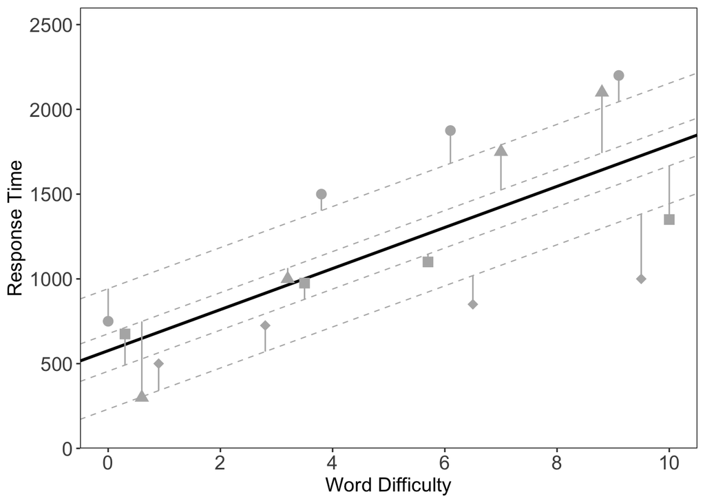

```r
ggplot(figuredata, aes(x = xvar, y = yvar)) +
  geom_abline(slope = model_slope, intercept = model_intercept,
              linetype = "solid", color = "black", size = 1) +
  geom_abline(mapping = aes(slope = model_slope, intercept = intercepts),
              linetype = "dashed", color = "grey70", size = .4) +
  geom_point(aes(shape = PID), size = 3.25, color = "grey70") +
  scale_shape_manual(values = c(15, 16, 17, 18)) +
  geom_segment(aes(x = xvar, xend = xvar,
                   y = yvar, yend = fitted(random_intercepts.mod)),
               color = "grey70") +
  scale_y_continuous(expand = c(0, 0), breaks = c(0, 500, 1000, 1500, 2000, 2500),
                     limits = c(0, 2600)) +
  scale_x_continuous(expand = c(0, 0), breaks = c(0, 2, 4, 6, 8, 10),
                     limits = c(-0.5, 10.5)) +
  theme(panel.background = element_blank(),
        panel.grid.major = element_blank(),
        panel.grid.minor = element_blank(),
        panel.border = element_rect(colour = "black", fill = NA),
        legend.position = "none",
        axis.text = element_text(size = 14),
        axis.title = element_text(size = 14)) +
  labs (x = "Word Difficulty", y = "Response Time")
```

Save the figure

```r
ggsave("random_intercepts.png", units = "in", width = 9, height = 6, dpi = 300)
```

## Random intercepts and slopes plot

Build the model with random intercepts and slopes and view the summary output to look at the residuals

```r
random_slopes.mod <- lmer(yvar ~ 1 + xvar + (1 + xvar|PID), data = figuredata)

summary(random_slopes.mod)
```

```
## Linear mixed model fit by REML. t-tests use Satterthwaite's method [
## lmerModLmerTest]
## Formula: yvar ~ 1 + xvar + (1 + xvar | PID)
##    Data: figuredata
##
## REML criterion at convergence: 191.1
##
## Scaled residuals:
##     Min      1Q  Median      3Q     Max
## -1.0716 -0.4797 -0.1726  0.6937  1.0952
##
## Random effects:
##  Groups   Name        Variance Std.Dev. Corr
##  PID      (Intercept) 61192    247.37
##           xvar         5854     76.51   -0.40
##  Residual              5638     75.08
## Number of obs: 16, groups:  PID, 4
##
## Fixed effects:
##             Estimate Std. Error      df t value Pr(>|t|)
## (Intercept)  561.105    128.055   2.990   4.382   0.0222 *
## xvar         124.636     38.667   2.997   3.223   0.0485 *
## ---
## Signif. codes:  0 '***' 0.001 '**' 0.01 '*' 0.05 '.' 0.1 ' ' 1
##
## Correlation of Fixed Effects:
##      (Intr)
## xvar -0.415
```

Extract the individual participant intercepts and slopes from this model and add them to the data frame

```r
figuredata$intercepts2 <- rep(coef(random_slopes.mod)$PID[,1], each = 4)
figuredata$slopes <- rep(coef(random_slopes.mod)$PID[,2], each = 4)
```

Build plot

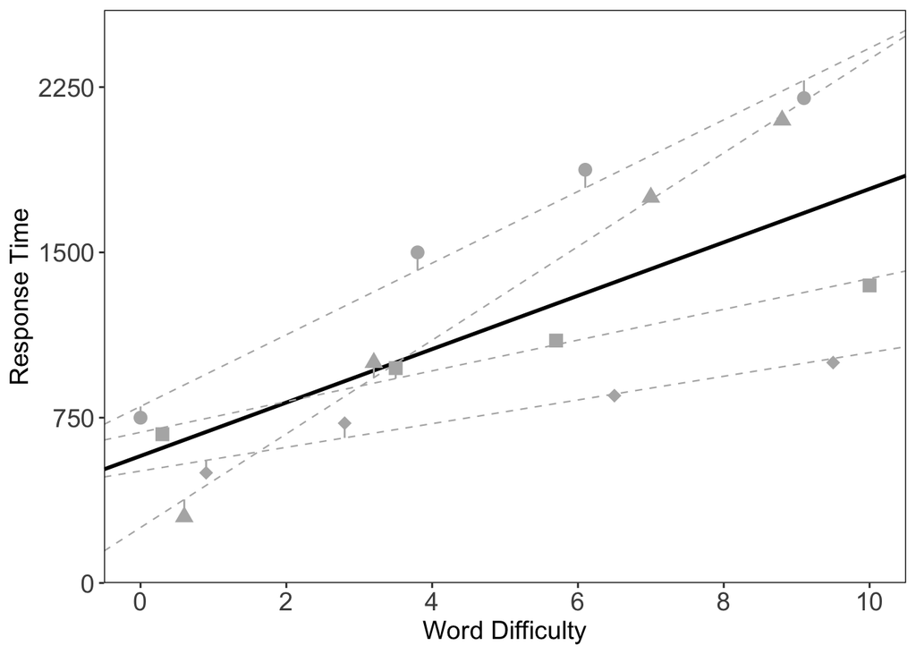

```r
ggplot(figuredata, aes(x = xvar, y = yvar)) +
  geom_abline(slope = model_slope, intercept = model_intercept,
              linetype = "solid", color = "black", size = 1) +
  geom_abline(mapping = aes(slope = slopes,
                            intercept = intercepts2, linetype = PID),
              linetype = "dashed", color = "grey70", size = .4) +
  geom_point(aes(shape = PID), size = 3.25, color = "grey70") +
  scale_shape_manual(values = c(15, 16, 17, 18)) +
  geom_segment(aes(x = xvar, xend = xvar,
                   y = yvar, yend = fitted(random_slopes.mod)),
               color = "grey70") +
  scale_y_continuous(expand = c(0, 0), breaks = c(0, 750, 1500, 2250),
                     limits = c(0, 2600)) +
  scale_x_continuous(expand = c(0, 0), breaks = c(0, 2, 4, 6, 8, 10),
                     limits = c(-0.5, 10.5)) +
  theme(panel.background = element_blank(),
        panel.grid.major = element_blank(),
        panel.grid.minor = element_blank(),
        panel.border = element_rect(colour = "black", fill = NA),
        legend.position = "none",
        axis.text = element_text(size = 14),
        axis.title = element_text(size = 14)) +
  labs (x = "Word Difficulty", y = "Response Time")
```

Save the figure

```r
ggsave("random_slopes.png", units = "in", width = 9, height = 6, dpi = 300)
```